# Case Study: Anthropometric Data

Wednesday, March 10, 2021 @ 07:17 PM

### Load the Package(s)

```r
library(tidyverse)
library(moments) # for skewness and kurtosis
library(gridExtra)   # for bonus end content
library(grid)        # for bonus end content
```

### Problem Description

In our [Modeling & Regression: Theory and Line Fitting](https://stat-jet-asu.github.io/StatisticalDataAnalysis1/Slides/ModelingRegression01.html#1) slides, we posed the question of whether people are squares, as asserted by the ancient Roman architect Vitruvius. In other words, are people’s heights and armspans equal? Refer to the [description page](https://stat-jet-asu.github.io/Datasets/InstructorDescriptions/anthropometric.html) for Dr. Thomley’s [anthropometric dataset](https://raw.githubusercontent.com/STAT-JET-ASU/Datasets/master/Instructor/anthropometric.csv) for context regarding the data we will use to assess this claim. These data were collected over several semesters from students in Dr. Thomley’s STT1810 and STT3850 courses. Students measured one another using tape measures and/or yardsticks. Gender was self-identified.

Before doing any modeling, it is good practice to conduct exploratory data analysis on the variables in order to assess shape and determine whether there are any outliers or other anomalies, which might affect our models.

Use `tidyverse` methods (e.g., `dplyr` and `ggplot`) as much as possible when answering the questions.

### Import the Dataset

Use `read_csv` to import the data, then `glimpse` and `head` to display the dataset structure.

```r
anthro <- read_csv(file = url("https://raw.githubusercontent.com/STAT-JET-ASU/Datasets/master/Instructor/anthropometric.csv"))
glimpse(anthro)
```

```
Rows: 547
Columns: 9
$ gender   <chr> "female", "female", "female", "female", "female", "female", "…
$ ideal    <dbl> 64, 64, 65, 63, 68, 64, NA, 65, 66, 63, 62, 60, 65, 68, 64, 6…
$ height   <dbl> 59.75, 59.75, 60.00, 60.00, 60.00, 60.00, 60.50, 60.50, 61.00…
$ armspan  <dbl> 58.5, 58.5, 61.0, 58.0, 62.0, 60.0, 60.0, 61.5, 63.0, 59.0, 6…
$ forearm  <dbl> 15.00, 15.00, 16.00, 15.00, 15.00, 15.00, 15.50, 15.00, 16.50…
$ hand     <dbl> 6.50, 6.50, 7.00, 6.25, 6.00, 6.00, 5.50, 7.00, 7.00, 6.00, 6…
$ leg      <dbl> 16.00, 16.00, 16.00, 16.25, 18.00, 16.00, 17.75, 16.50, 19.00…
$ foot     <dbl> 8.50, 8.50, 8.50, 9.50, 9.00, 8.00, 8.50, 8.50, 9.50, 8.75, 8…
$ semester <chr> "F15", "F15", "F13", "F15", "S13", "Sum13", "S14", "Sum14", "…
```

```r
head(anthro)
```

```
# A tibble: 6 x 9
  gender ideal height armspan forearm  hand   leg  foot semester
  <chr>  <dbl>  <dbl>   <dbl>   <dbl> <dbl> <dbl> <dbl> <chr>
1 female    64   59.8    58.5      15  6.5   16     8.5 F15
2 female    64   59.8    58.5      15  6.5   16     8.5 F15
3 female    65   60      61        16  7     16     8.5 F13
4 female    63   60      58        15  6.25  16.2   9.5 F15
5 female    68   60      62        15  6     18     9   S13
6 female    64   60      60        15  6     16     8   Sum13
```

### Exploratory Analysis 1

#### What genders are present in the data?

Create a frequency table and barplot for the variable `gender`.

```r
anthro %>%
  count(gender)
```

```
# A tibble: 4 x 2
  gender     n
  <chr>  <int>
1 both       1
2 female   271
3 male     273
4 other      2
```

For exploration, we can do a basic barplot. The heights of the bars should match the table. Notice there are very few people (so far) who have self-identified anything besides `male` or `female`.

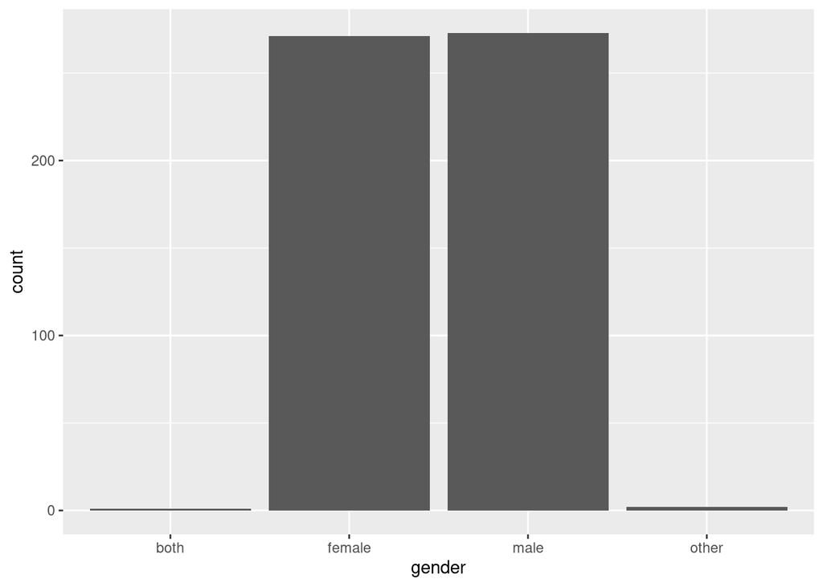

```r
ggplot(anthro, aes(x = gender)) +
  geom_bar()
```

For presentation, we should give the plot an informative title and axis labels. Adding color is optional, but it can be nice to have. Try to keep colorblind-safe options in mind if you are using colors to convey information.

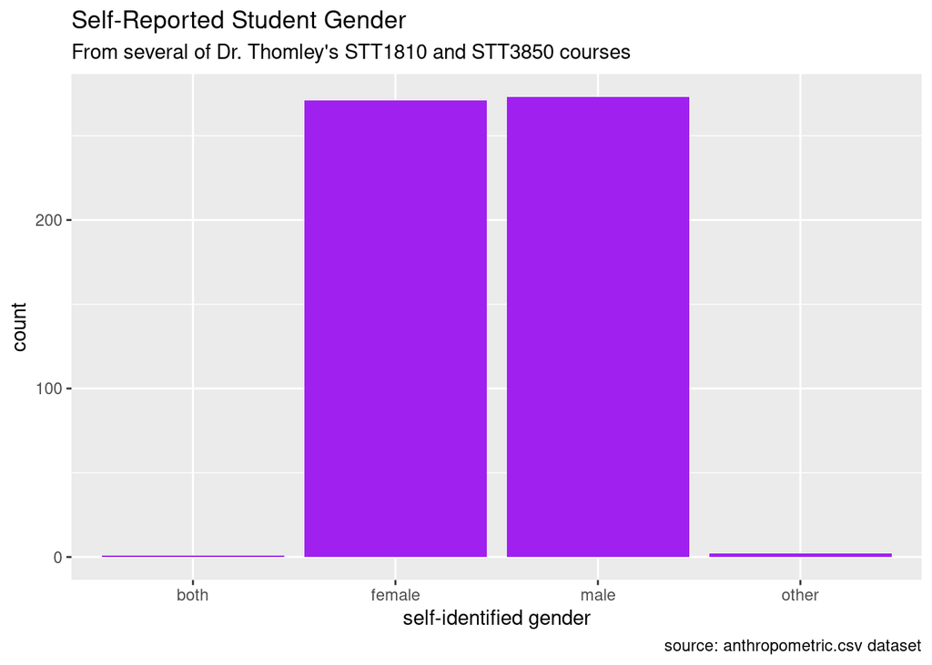

```r
ggplot(anthro, aes(x = gender)) +
  geom_bar(fill = "purple") +
  labs(title = "Self-Reported Student Gender",
       subtitle = "From several of Dr. Thomley's STT1810 and STT3850 courses",
       x = "self-identified gender",
       caption = "source: anthropometric.csv dataset")
```

#### What semesters are present in the data?

Create a frequency table and barplot for the variable `semester`.

The code is the same as what we used above, just change the variable. Notice that the semesters are in alphabetical order, which is `R`’s default for character vectors.

```r
anthro %>%
  count(semester)
```

```
# A tibble: 11 x 2
   semester     n
   <chr>    <int>
 1 F13         62
 2 F15         64
 3 S13         72
 4 S14         96
 5 S16         59
 6 S17         82
 7 S18         26
 8 Sum13       26
 9 Sum14       12
10 Sum15       38
11 Sum16       10
```

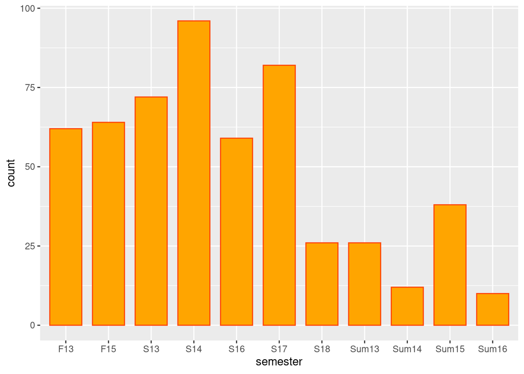

```r
# with some example bar formatting
ggplot(anthro, aes(x = semester)) +
  geom_bar(fill = "orange", color = "orangered", width = 0.75)
```

#### Putting the semesters in correct order

Make `semester` a `factor` with the categories in the correct order. Then make frequency table and barplot using this new variable.

Academic years go spring, summer, fall. Put the years in ascending order.

```r
sem_levels <- c("S13", "Sum13", "F13", "S14", "Sum14", "Sum15", "F15", "S16", "Sum16", "S17", "S18")

anthro <- anthro %>%
  mutate(semester = factor(semester, levels = sem_levels))

anthro %>%
  count(semester)
```

```
# A tibble: 11 x 2
   semester     n
   <fct>    <int>
 1 S13         72
 2 Sum13       26
 3 F13         62
 4 S14         96
 5 Sum14       12
 6 Sum15       38
 7 F15         64
 8 S16         59
 9 Sum16       10
10 S17         82
11 S18         26
```

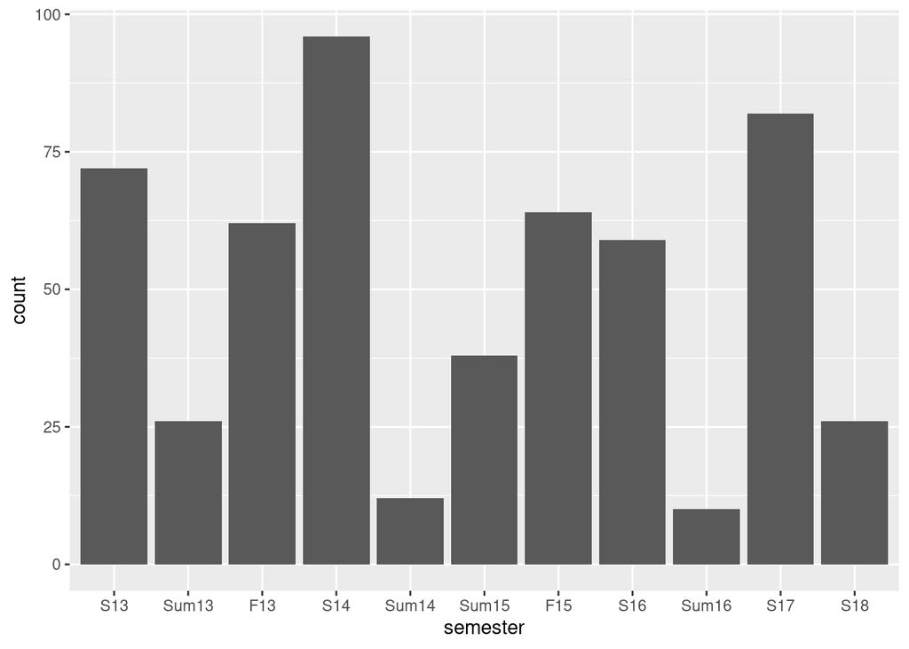

```r
ggplot(anthro, aes(x = semester)) +
  geom_bar()
```

### Exploratory Analysis 2

#### Plots and summaries for `height`

Create a histogram, density plot, and boxplot for the variable `height`. Also calculate skewness, kurtosis, and the upper and lower fences.

This shows several `bin` options for the histogram. You often have to try several options to get a good representation. These data seem to have more than one mode (peak or local maxima)—either two or three, judging by the histograms and density plot. We may need to explore the data in groups to uncover what is going on.

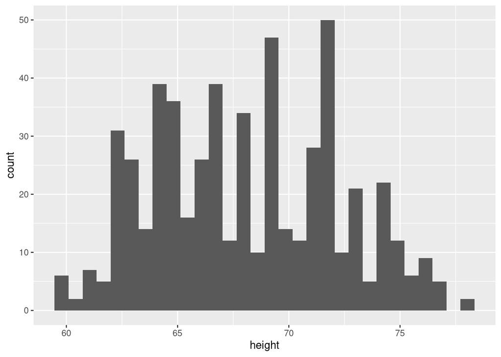

```r
ggplot(anthro, aes(x = height)) +
  geom_histogram()   # default number of bins is about 30
```

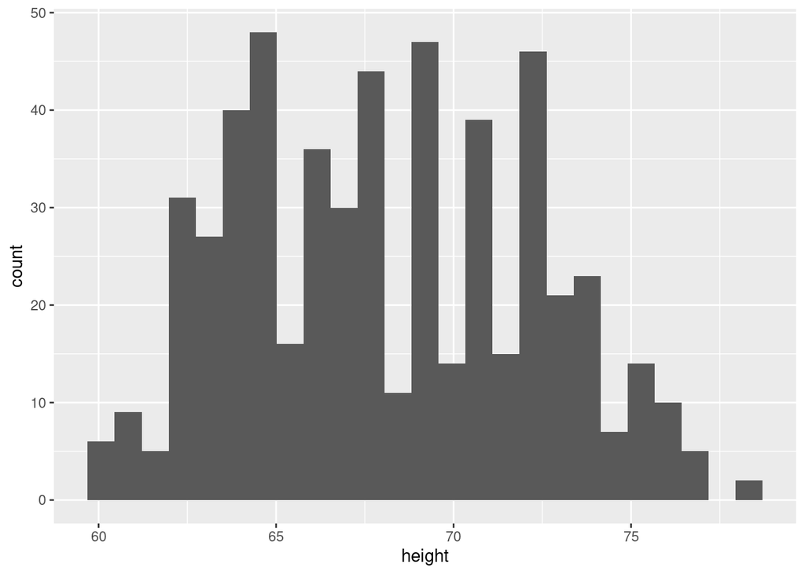

```r
ggplot(anthro, aes(x = height)) +
  geom_histogram(bins = 25)   # we will get about 25 bins
```

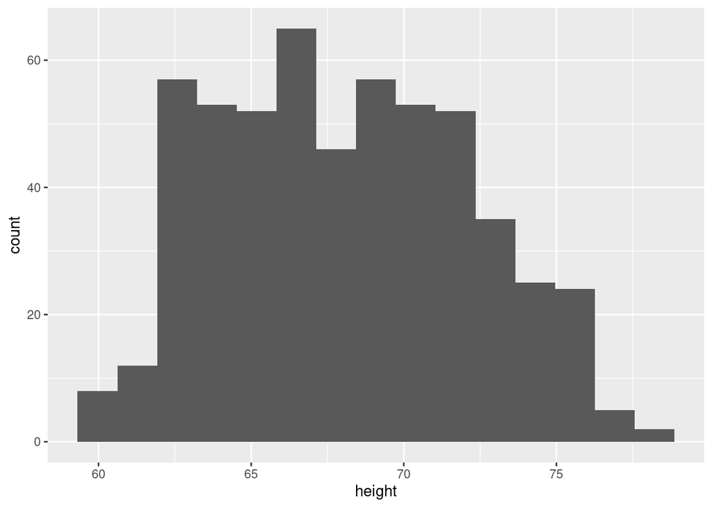

```r
ggplot(anthro, aes(x = height)) +
  geom_histogram(bins = 15)   # we will get about 15 bins
```

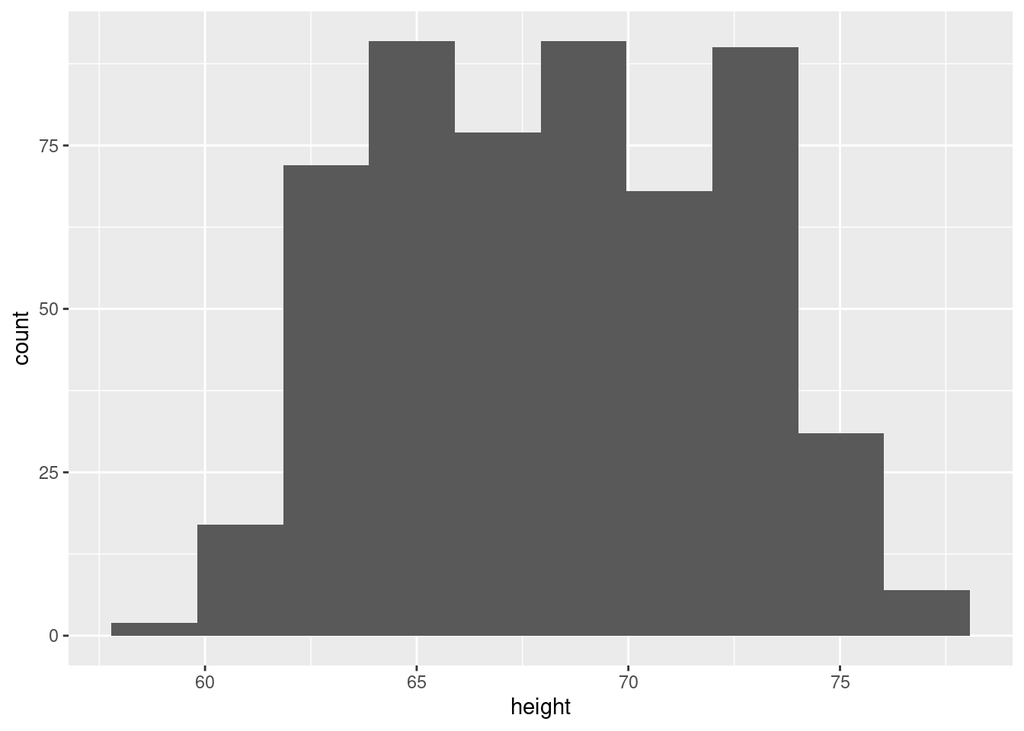

```r
ggplot(anthro, aes(x = height)) +
  geom_histogram(bins = 10)   # we will get about 10 bins
```

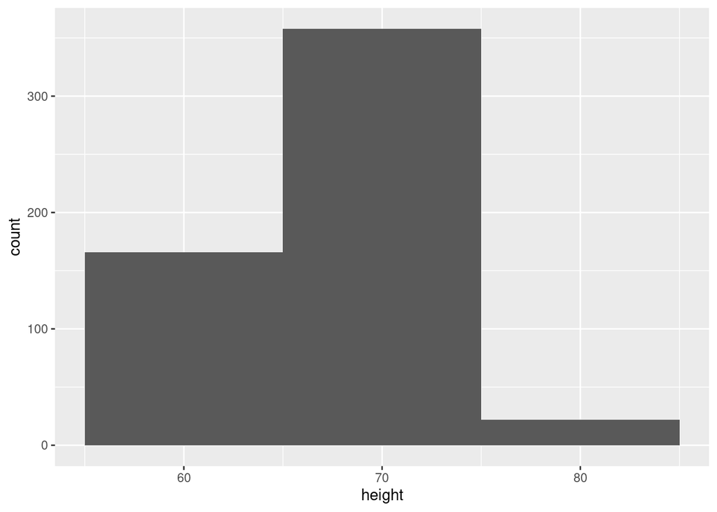

```r
ggplot(anthro, aes(x = height)) +
  geom_histogram(binwidth = 10)  # bins are 10 units wide
```

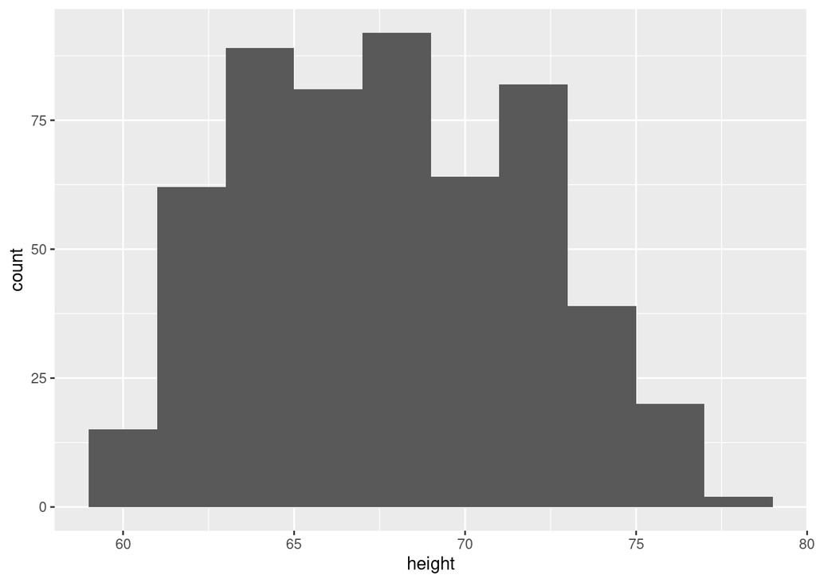

```r
ggplot(anthro, aes(x = height)) +
  geom_histogram(binwidth = 2)    # bins are 2 units wide
```

We can also add color and labels to histograms.

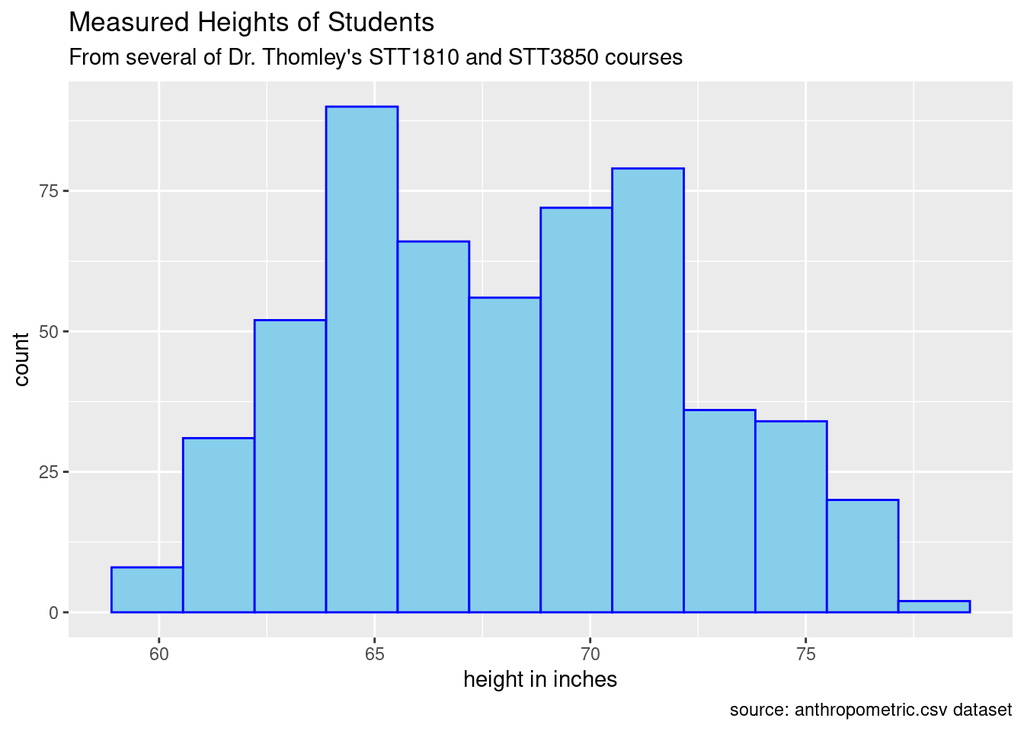

```r
ggplot(anthro, aes(x = height)) +
  geom_histogram(bins = 12, fill = "skyblue", color = "blue") +
  labs(title = "Measured Heights of Students",
       subtitle = "From several of Dr. Thomley's STT1810 and STT3850 courses",
       x = "height in inches",
       caption = "source: anthropometric.csv dataset")
```

The other plots follow the same pattern. The variable the same (same `aes`), just change the type of plot (different `geom`).

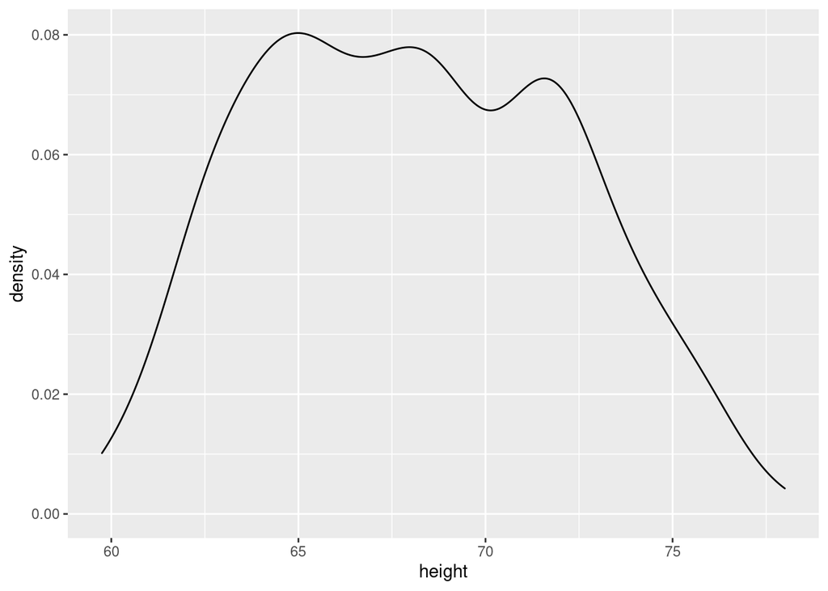

```r
ggplot(anthro, aes(x = height)) +
  geom_density()
```

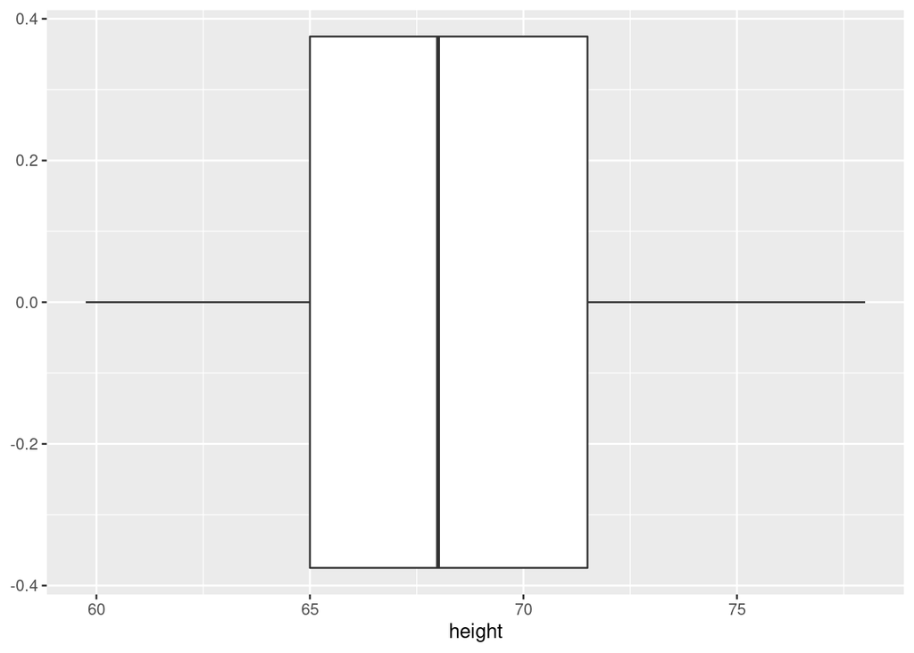

```r
ggplot(anthro, aes(x = height)) +
  geom_boxplot()
```

We can calculate all four statistics in one `summarize` statement. Refer to the entries for skewness and kurtosis in the glossary for more information. There is missing data, so we need to use `na.rm = TRUE` to ignore these `NA` values.

```r
anthro %>%
  summarize(skew = skewness(height, na.rm = TRUE),
            kurt = kurtosis(height, na.rm = TRUE),
            LF   = fivenum(height)[2] - 1.5 * IQR(height, na.rm = TRUE),
            UF   = fivenum(height)[4] + 1.5 * IQR(height, na.rm = TRUE))
```

```
# A tibble: 1 x 4
   skew  kurt    LF    UF
  <dbl> <dbl> <dbl> <dbl>
1 0.138  2.11  55.2  81.2
```